# Lecture 01: Statistical Odds

Module on Logistic Regression

# Lecture Goals and Premise

So far in this class we have worked with ANOVA and Regression models. Specifically, we used a set of variables (both categorical and numeric) **to predict a numeric response.** What happens when the response is categorical? Specifically, what to do if it is a binary response (two outcomes).

We will eventually use Logistic Regression to model this type of data but we need to build up some background before getting there. Today we will

- Introduce Statistical Odds,
  - and relate it to sample proportions.
- Start the process of determining if odds vary by other variables.

# Motivating Example

The Youth Risk Behavior Surveillance System (YRBSS) is a public health initiative by the Center for Disease Control and Prevention (CDC) that monitors six key categories of health-risk behaviors among high school students. The YRBSS is conducted biannually in the spring semester and has been conducted regularly since 1991. We will look at a subset of the survey from 2023.

Specifically, we will look to determine if demographic variables are associated with whether a high school was bullied on school property in the preceding 12 months.

[figure not shown]

**Sources:** Data: (Centers for Disease Control and Prevention 2024). Clipart: (Brener et al. 2024).

```r
yrbss <- read_csv("https://tjfisher19.github.io/data/cdc_yrbss_2023.csv", show_col_types = FALSE)
glimpse(yrbss)
```

```
Rows: 17,605
Columns: 6
$ Age               <chr> "14 years old", "16 years old", "14 years old", "16 …
$ Sex               <chr> "Female", "Male", "Male", "Male", "Male", "Female", …
$ Grade             <chr> "9th grade", "11th grade", "9th grade", "9th grade",…
$ Height            <dbl> 1.65, 1.68, 1.85, 1.80, 1.83, 1.52, 1.65, 1.63, 1.70…
$ Weight            <dbl> 81.65, 74.84, 56.70, 72.58, 74.84, 73.48, 61.24, 53.…
$ Bullied_at_School <chr> "No", "No", "No", "No", "No", "No", "No", "No", "No"…
```

The Height variable is recorded in meters and the Weight is recorded in kilograms. All other variables are input as character variables but represent categories within a factor variable.

## Statistical Questions

The first step in an analysis is understanding the questions we are looking to answer:

- Which variable is the response variable in this problem?
  - The character variable of whether the student had been bullied or not, “Yes” or “No” respectively.
- What are the potential predictor variables?
  - The student’s Age, Sex, Grade, Height and Weight.
- What is fundamentally different about this problem compared to other regression problem you’ve encountered to date?
  - Here, a categorical variable (whether or not a student has been bullied) is the response variable!

## Why not use standard techniques?

In our study of linear regression we saw that categorical variables can be represented as numeric indicator (or dummy) variables. We may be inclined to convert that categorical response variable into a number (0 and 1).

Below we perform some light data process and then build a jittered scatterplot of the response with the students Height as a potential predictor variable. We also overlay a linear regression line on the plot.

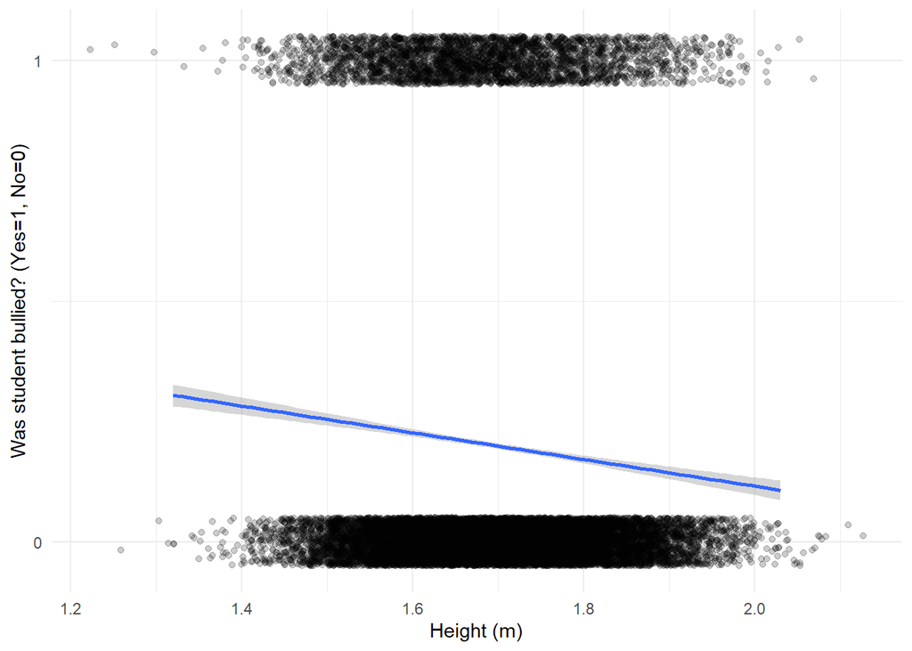

```r
yrbss <- yrbss |>
  mutate(Bullied_Indicator = ifelse(Bullied_at_School=="Yes", 1, 0) )

ggplot(yrbss, aes(x=Height, y=Bullied_Indicator)) +
  geom_jitter(alpha=0.2, height=0.05, width=0.1) +
  geom_smooth(method="lm", formula=y~x) +
  scale_y_continuous(breaks=c(0,1) ) +
  theme_minimal() +
  labs(x="Height (m)",
       y="Was student bullied? (Yes=1, No=0)")
```

Based on this plot it should seem obvious that linear regression model is inappropriate for these data?

# Mathematical Background

When we fit a regression model, we are modeling **the mean outcome of a response variable measured on a continuous scale**. The idea of regression is that this “mean response” can possibly be affected or influenced by other variables (*i.e.*, the predictor variables). Mathematically, up to this point the models have been
$$\mu = E(Y) = \beta_0 + \beta_1X_1 + ... + \beta_pX_p$$
where $Y$ is normally distributed with mean $\mu | X_1, X_2, ..., X_p$ and constant variance $\sigma^2$ (that is why we were always checking assumptions of normality and constant variance). However, in the working example of whether a high school student was bullied, the response is not a measured variable on a continuous scale; rather, **it is a binary classification** (was the student bullied in the previous 12 months: yes or no?). The modeling techniques we have covered thus far do not apply.

You might (and should!) remember from your introductory statistics course that such a binary categorical variable is usually described, not with a **mean** parameter, but rather a **proportion** (or probability) $p$. The appropriate probability distribution in this case is a **binomial distribution**.

## Review of the binomial distribution

What gives rise to the binomial distribution? Consider the following:

- We have a population that consist of observations that only two outcomes, which we generically refer to as **successes** and **failures**. The success outcome is the outcome of research interest (even if it does not seem ‘right’ to call it a success, such as a patient has cancer or a student is bullied).
- We randomly sample $n$ individuals from the population. If sampling randomly, this ensures the observations are independent.
- The statistic of interest is $Y$ = the number of successes in the sample.

If these conditions are satisfied, then $Y$ is said to be distributed as a binomial random variable with parameters $n$ and $p$. The parameter $p$ is the probability of a success, or $p=P(success)$, on any one trial or observation, and $n$ is the total number of trials or sample size. The form of the probability distribution is:
$$P(Y=y)=\left(\frac{n!}{y!(n-y)!}\right) p^y(1-p)^{(n-y)}$$
for $y=0,1,2,.,n$.

We denote this by writing $Y \sim Bin(n, p)$. The expected value (or average) of a binomial variable is $np$, and the standard deviation of a binomial distribution is $\sigma = \sqrt{np(1-p)}$.

**As researchers, the key feature we are interested in is $p$, the true probability of success.** The parameter $p$ serves as a summary description of the outcome (response) in cases where the response variable is binary (for a continuous response variables, the mean was the summary description).

Consider the following scenarios:

- **Binomial scenario: Random guessing.** Suppose you are to take a quiz that has ten multiple-choice questions, where each question has 4 possible responses (of which only one is correct). You failed to study for the test, so you just randomly guess on every question. What is the chance you get exactly two of the questions correct? If 60% is the minimum passing grade, what is the chance you fail the test?
  - QUESTION: What is $p$ in this scenario?
- **Binomial scenario: Public opinion polling.** Suppose that 1000 Americans will be randomly polled and asked their opinion of whether they approve or disapprove of a politician. What is the chance that such a sample would produce an estimate of an approval rating that is correct to within a margin of error of $\pm$ 3% of the true value?
  - QUESTION: What is $p$ in this scenario?
- **Binomial scenario: Bullied Students.** It is of interest to see the prevalence of bullying in high school students. Each student in the population (or the sample) has been bullied in the past 12 months or has not — a binary outcome. Prevalence of bullying would be calculated by the estimating the proportion of students who have been bullied.
  - QUESTION: What is $p$ in this scenario?

In real world applications, $p$ is unknown so it must be estimated. Once a sample is collected from the population under study, an unbiased estimate of $p$ is
$$\hat{p} = \frac{\#~successes}{n}$$

This seems pretty simple. For example, in the above examples suppose:

- you guessed on the multiple-choice quiz and got only two questions correct. What is $\hat{p}$ based on your sample of 10 guesses?
- in a random sample of 1000 Americans, 377 indicated approval of the politician. What is $\hat{p}$ based on this sample?
- Using basic data handling skills, we calculate the prevalence of bullying among the high school students What is $\hat{p}$?

```r
yrbss |>
  summarize(Sum_Bullied = sum(Bullied_at_School=="Yes"),
            Sum_Not_Bullied = sum(Bullied_at_School=="No"),
            N = n(),
            Prop_Bullied = Sum_Bullied/n() ) |>
  kable(digits=4)
```

| Sum_Bullied | Sum_Not_Bullied | N | Prop_Bullied |
| --- | --- | --- | --- |
| 3522 | 14083 | 17605 | 0.2001 |

Here, $\hat{p} = 3522/17605 = 0.200$

Remember $p = P(success)$ and a “success” is whatever the researcher is interested in counting.

## Computing Odds

Another common approach to communicating this type of information is in the form of **odds of success** (*i.e.*, the odds of the event of interest). The odds of an event is defined as the probability that the event happens divided by the probability it does not happen, or

$$Odds = \frac{P(success)}{P(not~success)}$$
This can be estimated using the following:
$$Estimated~odds = \frac{ \frac{\#~successes}{n} }{ \frac{\#~failures}{n} } = \frac{\#~successes}{\#~failures}$$

**Bullied High School students.** What are the estimated odds a high school student has been bullied in the past 12 months?

Using the output from above, the odds a high school student has been bullied is $3522/14083$ or about $0.2501$.

Likewise, the odds a student has not been bullied is $14083/3522$ or $3.999$.

**Note**

Note that while probabilities can only range between 0 and 1, **odds can take on any value from 0 to $\infty$.**

**Note**

When the probability of success is very small (near 0), the odds will take on a similar value.

| Probability of Success | 0.01 | 0.03 | 0.05 | 0.07 | 0.10 | 0.15 | 0.20 |
| --- | --- | --- | --- | --- | --- | --- | --- |
| Odds of Success | 0.0101 | 0.0309 | 0.0526 | 0.0753 | 0.1111 | 0.1765 | 0.2500 |

## Modeling Ideas

“**I thought this was a modeling course!**” It is, don’t worry! We can link regression modeling ideas by considering **the probability (or odds) of some event occurring is affected/related to other predictor variables.** For instance,

- the probability you approve of a certain politician might be predicted by your registered political party, or socio-economic demographics.
- the probability a high school student is a victim of bullying may be predicted by their class grade or their height.
  - The initial plot (although incorrect) provides some insight that taller students may be linked with lower rates of bullying – we’ll revisit this question next class.
  - One may expect that class standing influences the bullying rate (consider any teen movie from the 1980 or 1990s as evidence).

In such cases, we are (implicitly) building regression models, but the outcome is binary. The characteristic we will be modeling is the odds of success.

For example, let’s consider the odds of a high school student being a victim of bullying based on their class standing. First, some data handling to order the factor levels correspond to the student’s grade.

```r
yrbss <- yrbss |>
  mutate(Grade = factor(Grade,
                        levels=c("9th grade", "10th grade", "11th grade", "12th grade") )
  )
```

**Coding Note**

There are multiple ways to get frequency counts in R – you can use the `table()` function, or `group_by() |> summarize()` like we did earlier in the class.

We recommend using the `xtabs()` function as it has a formula-like input and generally separates the counts in an easy-to-read table. From here, you can quickly calculate the probability and odds.

```r
xtabs(~ Grade + Bullied_at_School, data=yrbss)
```

```
            Bullied_at_School
Grade          No  Yes
  9th grade  3619 1233
  10th grade 3819  992
  11th grade 3579  760
  12th grade 3066  537
```

For 9th graders, the odds of being bullied are $1233/3619=0.341$, for 10th grader it is $992/3819=0.260$, for 11th graders the odds $760/3579 = 0.212$ and for 12th graders the odds are $537/3066 = 0.175$.

As the student progresses in high school, the odds of being bullied in the previous year decrease.

## Odds Ratio

A way to compare two odds is through their ratio. For example, if we compared compare the odds of a freshman being bullied compared to a senior. We can calculate the ratio as

$$\frac{(1233/3619)}{(537/3066)} = \frac{0.341}{0.175} = 1.95$$
So the odds of freshmen being a victim of bullying is 1.95 greater (nearly 2 times as likely) as that of a senior.

# Working Example

We now recap the findings and look at a few others features from our working example.

## Base Level Odds

The odds a high school student reported being bullied at school in the past year.

```r
xtabs(~ Bullied_at_School, data=yrbss)
```

```
Bullied_at_School
   No   Yes
14083  3522
```

So the odds a youth in the survey reported being bullied are $3522/14083 = 0.2501$.

## Odds by Class Standing

First, let’s compare the odds by class standing:

```r
xtabs(~ Grade + Bullied_at_School, data=yrbss)
```

```
            Bullied_at_School
Grade          No  Yes
  9th grade  3619 1233
  10th grade 3819  992
  11th grade 3579  760
  12th grade 3066  537
```

**QUESTIONS**:

1. What are the odds that a freshman reported being bullied?
   - $1233/3619 = 0.3407$, which is elevated compare to the overall odds.
2. What are the odds that a sophomore reported being bullied?
   - $992/3819 = 0.2598$, not much different than the overall odds.
3. What are the odds that a junior reported being bullied?
   - $760/3579 = 0.2123$, which is smaller compared to the sophomores.
4. Likewise, for seniors we have $537/3066 = 0.1751$.
5. In terms of odds ratios, we can make the following
   - The odds a freshmen has been bullied is $(1233/3619)/(992/3819) = 1.312$ times more likely than that of a sophomore.
   - The odds a freshmen has been bullied is $(1233/3619)/(760/3579) = 1.604$ times more likely than that of a junior.
   - The odds a freshmen has been bullied is $(1233/3619)/(537/3066) = 1.945$ times more likely than that of a senior.

## Visualizing Binary Outcomes

Plotting categorical data can be a challenge, particularly when multiple categorical variables are involved. Here we can use bar graphs of the proportions to get a decent visual that helps *tell the story*.

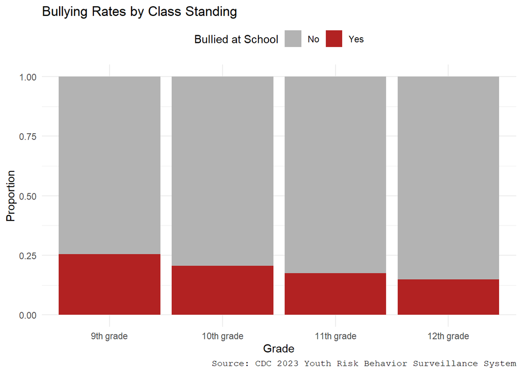

```r
ggplot(yrbss) +
  geom_bar(aes(x=Grade, fill=Bullied_at_School), position="fill" ) +
  scale_fill_manual(values=c("gray70", "firebrick")) +
  labs(x="Grade", y="Proportion", fill="Bullied at School",
       title="Bullying Rates by Class Standing",
       caption="Source: CDC 2023 Youth Risk Behavior Surveillance System") +
  theme_minimal() +
  theme(plot.caption = element_text(family="mono"),
        legend.position="top")
```

Visually we can see the proportion of students who report being victims of bullying at school decrease at higher grade levels.

## Odds by Height

We began the lecture by looking at a plot whether students were bullied based on their heights. It is difficult to analyze this type of data with summary data.

Fortunately, the provided data has 17,605 observations and the Height measurements of students have been rounded to two decimal places (*e.g*, 1.65 meters). Many students will have the same height. We can calculate the odds for each unique height and make a plot to look for patterns.

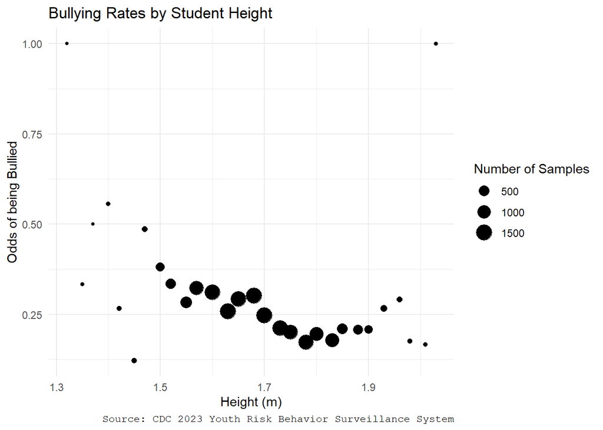

```r
bullied_by_height <- yrbss |>
  group_by(Height) |>
  summarize(Odds = sum(Bullied_at_School=="Yes")/sum(Bullied_at_School=="No"),
            N = n())

ggplot(bullied_by_height, aes(x=Height, y=Odds, size=N) ) +
  geom_point() +
  labs(x="Height (m)",
       y="Odds of being Bullied",
       size="Number of Samples",
       title="Bullying Rates by Student Height",
       caption="Source: CDC 2023 Youth Risk Behavior Surveillance System") +
  theme_minimal() +
  theme(plot.caption = element_text(family="mono"))
```

A few things can be noted in this plot.

- Two heights reports odds of 1 – this is due to small samples sizes at those heights (a height of 1.32 meters and 2.03 meters).
- For the remaining heights, there is a general decreasing trend in the odds.

Overall, it appears there is likely a decreasing trend in the odds of being bullied as a student gets taller.

## References

Brener, Nancy D., Jonetta J. Mpofu, Kathleen H. Krause, Sherry Everett Jones, Jemekia E. Thornton, Zachary Myles, William A. Harris, et al. 2024. “Overview and Methods for the Youth Risk Behavior Surveillance System — United States, 2023.” *MMWR Supplements* 73 (4): 1–12. https://doi.org/10.15585/mmwr.su7304a1.

Centers for Disease Control and Prevention. 2024. “2023 Youth Risk Behavior Survey Data.” Atlanta, GA: CDC Website.